# DeepMetrica Customer Segmentation Analysis - Websites Using Hotjar

Tugrul Ozsoy

27 Eylül 2020

# 1 Introduction

The data we analyzed consisting of the 20,000 websites using the technology of our main competitor Hotjar. Domain, Website Language, Global and Local Traffic Rank and Number of Referring Domains are the variables. The dataset is exported from `hunter.io` and enhanced by `Alexa Rank` tool of `SEO Tools for Excel Add-on`.

Hotjar is one of the strongest technology giving service in heatmaps and session recording to websites.

Here, you can see some visuals about Hotjar:

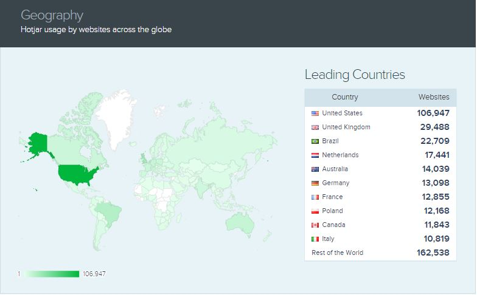

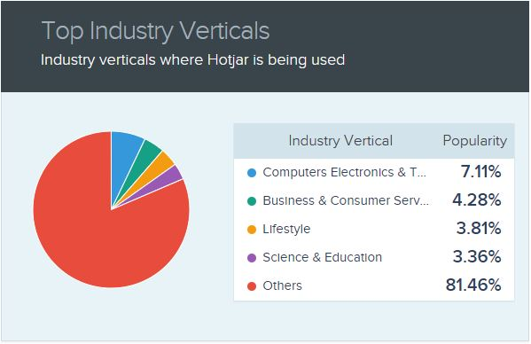

The websites purchased Hotjar have verticals mostly like Computer Electronics&Technology, Business&Consumer Services, and Others which can be consisted of News&Media, Arts&Entertainment, E-commerce, etc.

[figure not shown]

Hotjar is also very popular among the sites having the most monthly visits around the world as Google, Taboola, or Mediafire.

# 2 Data Analyses

## 2.1 Alexa Ranking of Websites

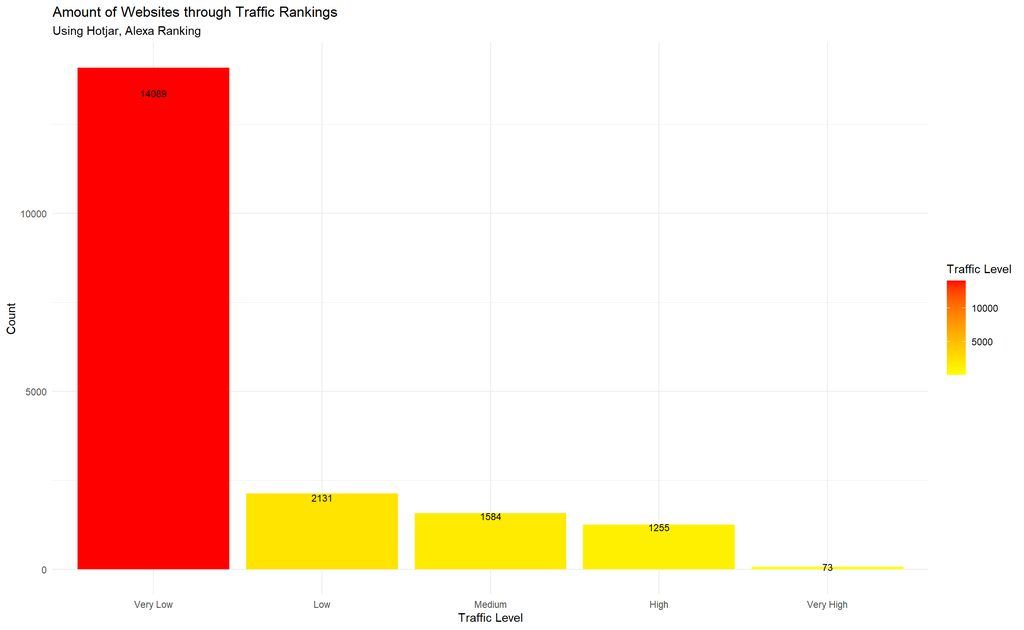

When we group the 20k websites using Hotjar by their Alexa rankings. Alexa rankings which show traffic levels are categorized as:

Very High -> Lower than 5000

High -> Between 5000 and 100000

Medium -> Between 100000 and 250000

Low -> Between 250000 and 500000

Very Low -> Higher than 500000

Since our sample data contains the websites which are in a very large interval of 294-33,474,711 Alexa Global Rank, and total number of elements are only 20K; most of the websites stay as outliers.

With the help of this chart, we can deduce that rather than websites having only high traffic levels, domains having least monthly visits and almost non-traffic at all are also eager to demand this kind of service. They prefer Hotjar more than we guess to enhance their UX and increase their traffic and clicks. However, it looks like majority gains no benefit still.

## 2.2 Referring Domains

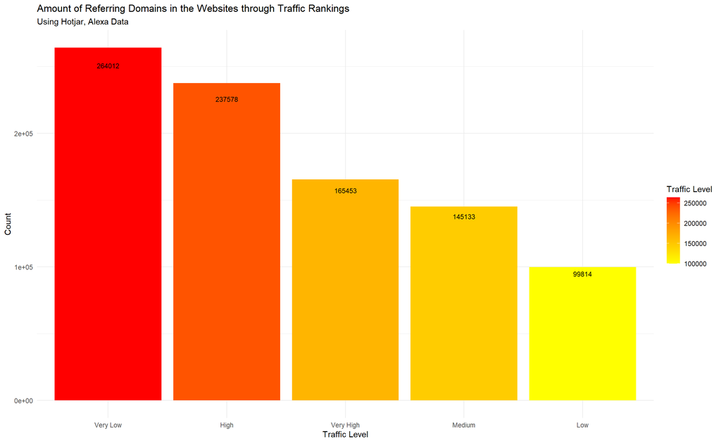

Since there are lots of domains having very low traffic, total number of referring links of that category deviated the chart. However, not much as we see by High Traffic Level is still on position 2.

## 2.3 Language of Websites

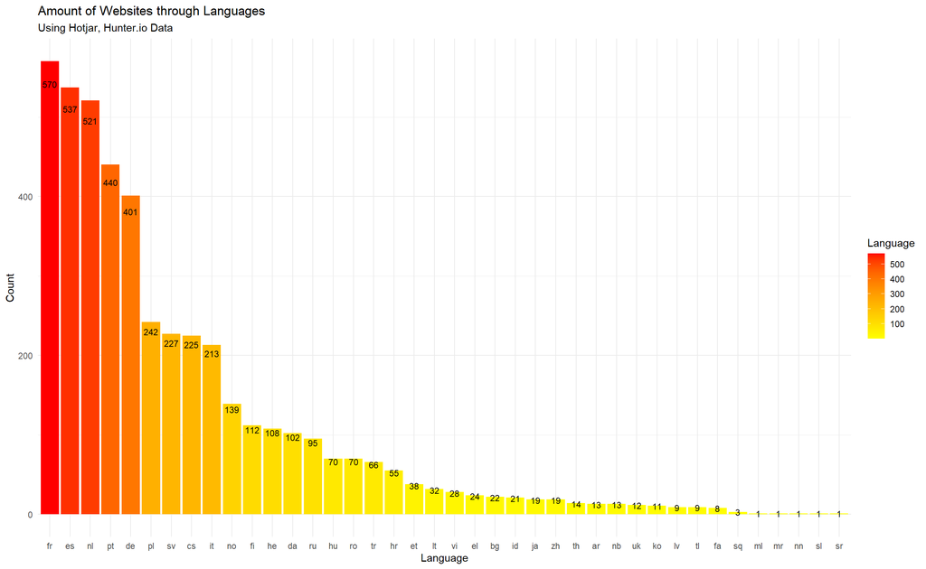

When we group the 20k websites using Hotjar by the language used, and when we exclude English to prevent the deviation, we observe that French, Spanish, Dutch, Portuguese and German are used in most of them. IT IS ALSO A DEDUCTION WHICH IS COMPATIBLE WITH THE CHARTS IN THE BEGINNING OF REPORT. We can deduce that Hotjar making sells after United States to the countries as:

Websites of FRANCE and SWITZERLAND with high traffic ranking:

`caradisiac.com` with Alexa Ranking 5,637 and 118 in France  
`jeuneafrique.com` with Alexa Ranking 11,841 and 2,778 in France  
`developpement-durable.gouv.fr` with Alexa Ranking 18,283  
`local.ch` with Alexa Ranking 20,519 and 82 in Switzerland  
`tdg.ch` with Alexa Ranking 26,729 and 158 in Switzerland

Websites of ARGENTINA, COLOMBIA and CHILE with high traffic ranking:

`clarin.com` with Alexa Ranking 1,377 and 16 in Argentina  
`eltiempo.com` with Alexa Ranking 2,309 and 23 in Colombia  
`ripley.cl` with Alexa Ranking 4,498 and 27 in Chile  
`elespectador.com` with Alexa Ranking 6,519 and 46 in Colombia  
`semana.com` with Alexa Ranking 6,565 and 52 in Colombia

Websites of BELGIUM and NETHERLANDS with high traffic ranking:

`ugent.be` with Alexa Ranking 22,125 and 80 in Belgium  
`zimmo.be` with Alexa Ranking 22,227 and 62 in Belgium  
`weeronline.nl` with Alexa Ranking 26,341 and 150 in Netherlands  
`voetbalzone.nl` with Alexa Ranking 33,949 and 390 in Netherlands

Websites of BRAZIL and PORTUGAL with high traffic ranking:

`otvfoco.com.br` with Alexa Ranking 486 and 16 in Brazil  
`sapo.pt` with Alexa Ranking 1,831 and 4 in Portugal  
`passeidireto.com` with Alexa Ranking 3,502 and 49 in Brazil  
`cifraclub.com.br` with Alexa Ranking 3,874 and 97 in Brazil  
`clicrbs.com.br` with Alexa Ranking 4,411 and 135 in Brazil

Websites of GERMANY and AUSTRIA with high traffic ranking:

`gamestar.de` with Alexa Ranking 7,978 and 206 in Germany  
`mjam.net` with Alexa Ranking 24,443 and 75 in Austria  
`gamepro.de` with Alexa Ranking 38,808 and 1,089 in Germany  
`wlw.de` with Alexa Ranking 43,223 and 2,399 in Germany